# BIOSTAT M215 Lab 9: Competiting Risks

Author

Zian Zhuang (Lab 9)

```r
rm(list=ls())
library(cmprsk)
library(KMsurv)
library(survival)
library(tidyverse)
```

# Competing Risks Regression and Cumulative Incidence Analysis

## Cause-specific hazards

```r
# load data
data(pbc)
pbc <- pbc %>%
  filter(is.na(trt)==F) %>%
  mutate(log_albumin = log(albumin),
         log_bili = log(bili),
         log_protime = log(protime))
table(pbc$status)
```

```
  0   1   2
168  19 125
```

We see that 19 subjects have `status = 1` (event 1), 125 subjects have `status = 2` (event 2), and 168 subjects have neither event.

Now, we fit the model:

```r
cox.model1 <- coxph(Surv(time, status==2) ~ age + log_albumin +
                      log_bili + log_protime + edema, data = pbc, x = T)
summary(cox.model1)
```

```
Call:
coxph(formula = Surv(time, status == 2) ~ age + log_albumin +
    log_bili + log_protime + edema, data = pbc, x = T)

  n= 312, number of events= 125

                 coef exp(coef)  se(coef)      z Pr(>|z|)
age          0.033223  1.033781  0.008658  3.837 0.000125 ***
log_albumin -3.059926  0.046891  0.724037 -4.226 2.38e-05 ***
log_bili     0.880056  2.411035  0.098742  8.913  < 2e-16 ***
log_protime  3.014012 20.368952  1.023946  2.944 0.003245 **
edema        0.785853  2.194277  0.298968  2.629 0.008575 **
---
Signif. codes:  0 '***' 0.001 '**' 0.01 '*' 0.05 '.' 0.1 ' ' 1

            exp(coef) exp(-coef) lower .95 upper .95
age           1.03378    0.96732   1.01639    1.0515
log_albumin   0.04689   21.32598   0.01134    0.1938
log_bili      2.41104    0.41476   1.98680    2.9259
log_protime  20.36895    0.04909   2.73769  151.5490
edema         2.19428    0.45573   1.22126    3.9425

Concordance= 0.844  (se = 0.02 )
Likelihood ratio test= 199.3  on 5 df,   p=<2e-16
Wald test            = 198.4  on 5 df,   p=<2e-16
Score (logrank) test = 269.6  on 5 df,   p=<2e-16
```

```r
cox.model2 <- coxph(Surv(time, status==1) ~ age + log_albumin +
                      log_bili + log_protime + edema, data = pbc, x = T)
summary(cox.model2)
```

```
Call:
coxph(formula = Surv(time, status == 1) ~ age + log_albumin +
    log_bili + log_protime + edema, data = pbc, x = T)

  n= 312, number of events= 19

                 coef exp(coef)  se(coef)      z Pr(>|z|)
age         -0.082467  0.920842  0.027861 -2.960  0.00308 **
log_albumin -1.327991  0.265009  2.416035 -0.550  0.58255
log_bili     0.890589  2.436563  0.278039  3.203  0.00136 **
log_protime -5.186536  0.005591  3.461644 -1.498  0.13406
edema        0.051955  1.053328  1.299239  0.040  0.96810
---
Signif. codes:  0 '***' 0.001 '**' 0.01 '*' 0.05 '.' 0.1 ' ' 1

            exp(coef) exp(-coef) lower .95 upper .95
age          0.920842     1.0860 8.719e-01    0.9725
log_albumin  0.265009     3.7735 2.327e-03   30.1852
log_bili     2.436563     0.4104 1.413e+00    4.2019
log_protime  0.005591   178.8480 6.324e-06    4.9439
edema        1.053328     0.9494 8.254e-02   13.4424

Concordance= 0.834  (se = 0.054 )
Likelihood ratio test= 25.85  on 5 df,   p=1e-04
Wald test            = 22.99  on 5 df,   p=3e-04
Score (logrank) test = 25.66  on 5 df,   p=1e-04
```

## `cmprisk` for Fine-Gray Proportional Subdistribution Hazards

`crr` fits the ’proportional subdistribution hazards’ regression model described in Fine and Gray (1999). This model directly assesses the effect of covariates on the subdistribution of a particular type of failure in a competing risks setting. The method implemented here is described in the paper as the weighted estimating equation.

```r
# simulated data to test
set.seed(10)
ftime <- rexp(200)
fstatus <- sample(0:2, 200, replace = TRUE)
cov <- matrix(runif(600), nrow = 200)
dimnames(cov)[[2]] <- c('x1','x2','x3')

print(z <- crr(ftime, fstatus, cov, failcode=1))
```

```
convergence:  TRUE
coefficients:
      x1       x2       x3
 0.26680 -0.05568  0.28050
standard errors:
[1] 0.4211 0.3812 0.3810
two-sided p-values:
  x1   x2   x3
0.53 0.88 0.46
```

```r
summary(z)
```

```
Competing Risks Regression

Call:
crr(ftime = ftime, fstatus = fstatus, cov1 = cov, failcode = 1)

      coef exp(coef) se(coef)      z p-value
x1  0.2668     1.306    0.421  0.633    0.53
x2 -0.0557     0.946    0.381 -0.146    0.88
x3  0.2805     1.324    0.381  0.736    0.46

   exp(coef) exp(-coef)  2.5% 97.5%
x1     1.306      0.766 0.572  2.98
x2     0.946      1.057 0.448  2.00
x3     1.324      0.755 0.627  2.79

Num. cases = 200
Pseudo Log-likelihood = -320
Pseudo likelihood ratio test = 1.02  on 3 df,
```

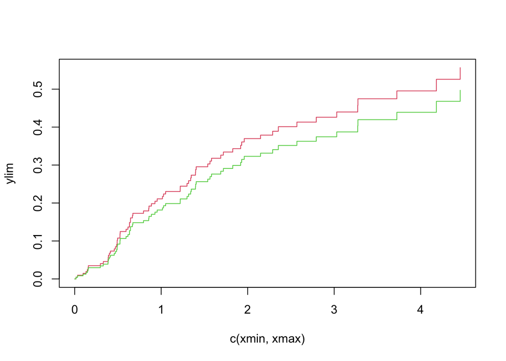

```r
z.p <- predict(z, rbind(c(.1,.5,.8), c(.1,.5,.2)))
plot(z.p,lty=1,color=2:3)
```

`predict` computes 1-exp(-B(t)), where B(t) is the estimated cumulative sub-distribution hazard obtained for the specified covariate values, obtained from the Breslow-type estimate of the underlying hazard and the estimated regression coefficients.

**Task2:** Fit a Fine and Gray model based on the PBC data set. Then predict and plot the CIF for an individual where all variables are set to their median values.

```r
data(pbc)
pbc <- pbc %>%
  filter(is.na(trt)==F) %>%
  mutate(log_albumin = log(albumin),
         log_bili = log(bili),
         log_protime = log(protime))
X <- pbc %>% select(age, log_albumin, log_bili, log_protime, edema)

model <- crr(pbc$time, pbc$status, X, failcode=1)
summary(model)

newdata <- apply(X, 2, median)
z.p <- predict(model, newdata)
plot(z.p,lty=1)
```

[output not shown]

Note that we can also include time-dependent covariates in model. For example, if z is a vector of covariate values, and uft is a vector containing the unique failure times for failures of the type of interest (sorted in ascending order), then the coefficients a, b and c in the quadratic (in time) model $az + bzt + czt^2$ can be fit by specifying cov1=z, cov2=cbind(z,z), tf=function(uft) cbind(uft,uft*uft).

```r
# quadratic in time for first cov
crr(ftime, fstatus, cov1 = cov,
    cov2 = cbind(cov[,1], cov[,1]), tf = function(Uft) cbind(Uft, Uft^2))
```

```
convergence:  TRUE
coefficients:
                            x1                             x2
                       2.16500                       -0.06664
                            x3 cbind(cov[, 1], cov[, 1])1*Uft
                       0.27490                       -3.25200
cbind(cov[, 1], cov[, 1])2*tf2
                       0.81900
standard errors:
[1] 0.9464 0.3797 0.3854 1.2590 0.2925
two-sided p-values:
                            x1                             x2
                        0.0220                         0.8600
                            x3 cbind(cov[, 1], cov[, 1])1*Uft
                        0.4800                         0.0098
cbind(cov[, 1], cov[, 1])2*tf2
                        0.0051
```

## `cuminc` for Cumulative Incidence Analysis

Load data:

```r
cif <- cuminc(pbc$time, pbc$status)
data.frame(time = cif$`1 1`$time, CIF = cif$`1 1`$est) %>% head
```

```
  time         CIF
1    0 0.000000000
2  533 0.000000000
3  533 0.003205128
4  732 0.003205128
5  732 0.006410256
6  737 0.006410256
```

```r
set.seed(2)
ftime <- rexp(100)
group <- factor(sample(1:3,100,replace=TRUE),1:3,c('a','b','c'))
fstatus <- sample(0:2,100,replace=TRUE)
strata <- sample(1:2,100,replace=TRUE)
print(xx <- cuminc(ftime,
                   fstatus,
                   group,
                   strata,
                   cencode = 0))
```

```
Tests:
      stat        pv df
1 1.598854 0.4495865  2
2 3.390543 0.1835493  2
Estimates and Variances:
$est
             1         2         3         4
a 1 0.27262599 0.3216446 0.3216446 0.3216446
b 1 0.08877315 0.3423257 0.3423257 0.3423257
c 1 0.23368736 0.4312495 0.4879272 0.4879272
a 2 0.38424403 0.5607109 0.5607109 0.5607109
b 2 0.31463271 0.4786961 0.5234407 0.5234407
c 2 0.20127996 0.3420399 0.3420399 0.3420399

$var
              1           2           3           4
a 1 0.008596053 0.009950848 0.009950848 0.009950848
b 1 0.002491270 0.009675072 0.009675072 0.009675072
c 1 0.006341967 0.011566190 0.012617195 0.012617195
a 2 0.010293273 0.022358101 0.022358101 0.022358101
b 2 0.007220502 0.010014466 0.010588994 0.010588994
c 2 0.005699657 0.010260038 0.010260038 0.010260038
```

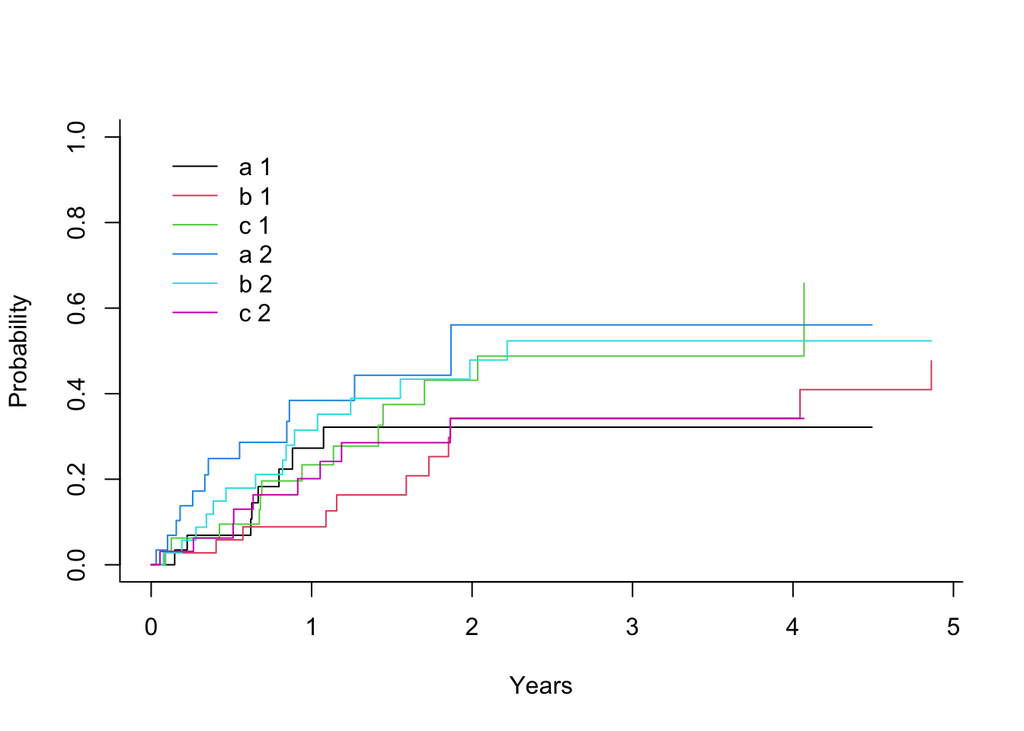

```r
plot(xx,lty=1,color=1:6)
```